# San Francisco Crime Classification-Neural Network Modeling

## Data

This dataset contains incidents of crime described by the San Francisco Police Department from January 1st 2003 to May 13th 2015. The data was collected from the police department reports. The features of this dataset are Dates, Category, Descript, DayOfWeek, PdDistrict, Resolution, Address, X, Y.

Dates-timestamp of the crime incident.

Category-category of the crime. Category is the target variable that I am going to predict.

Descript-description of the crime incident.

DayOfWeek-the day of the week the crime occured.

PdDistrict-name of the police department district.

Resolution-how the crime incident was resolved.

Address-the approximate street address of the crime incident.

X-longitude

Y-latitude

I am going to check these features for collinearity and will remove the features with high colliniarity so that I don't overfit the data so I assume I will not be using all these features in my model building (unless there happens to be no collinearity).

```python
import pandas as pd
```

```python
train = pd.read_csv("train_3.csv")
test = pd.read_csv("test_3.csv")
```

```python
import tensorflow as tf
from tensorflow import keras
```

```python
# importing libraries
import matplotlib
import matplotlib.pyplot as plt
import seaborn as sns

import pandas as pd
from sklearn.model_selection import train_test_split
from sklearn.metrics import precision_score, recall_score, confusion_matrix, classification_report, accuracy_score, f1_score
```

## Exploratory Data Analysis

### Describing the features of the data

The features that I believe are going to be most important in this data set is category because it is the target variable I am going to be predicting and also descript which will give a good description of the crime and what I think will be the best at predicting the type of crime that occured.

```python
train.head()
```

|  | Dates | Category | Descript | DayOfWeek | PdDistrict | Resolution | Address | X | Y |
| --- | --- | --- | --- | --- | --- | --- | --- | --- | --- |
| 0 | 2015-05-13 23:53:00 | WARRANTS | WARRANT ARREST | Wednesday | NORTHERN | ARREST, BOOKED | OAK ST / LAGUNA ST | -122.425892 | 37.774599 |
| 1 | 2015-05-13 23:53:00 | OTHER OFFENSES | TRAFFIC VIOLATION ARREST | Wednesday | NORTHERN | ARREST, BOOKED | OAK ST / LAGUNA ST | -122.425892 | 37.774599 |
| 2 | 2015-05-13 23:33:00 | OTHER OFFENSES | TRAFFIC VIOLATION ARREST | Wednesday | NORTHERN | ARREST, BOOKED | VANNESS AV / GREENWICH ST | -122.424363 | 37.800414 |
| 3 | 2015-05-13 23:30:00 | LARCENY/THEFT | GRAND THEFT FROM LOCKED AUTO | Wednesday | NORTHERN | NONE | 1500 Block of LOMBARD ST | -122.426995 | 37.800873 |
| 4 | 2015-05-13 23:30:00 | LARCENY/THEFT | GRAND THEFT FROM LOCKED AUTO | Wednesday | PARK | NONE | 100 Block of BRODERICK ST | -122.438738 | 37.771541 |

```python
test.head()
```

|  | Id | Dates | DayOfWeek | PdDistrict | Address | X | Y |
| --- | --- | --- | --- | --- | --- | --- | --- |
| 0 | 0 | 2015-05-10 23:59:00 | Sunday | BAYVIEW | 2000 Block of THOMAS AV | -122.399588 | 37.735051 |
| 1 | 1 | 2015-05-10 23:51:00 | Sunday | BAYVIEW | 3RD ST / REVERE AV | -122.391523 | 37.732432 |
| 2 | 2 | 2015-05-10 23:50:00 | Sunday | NORTHERN | 2000 Block of GOUGH ST | -122.426002 | 37.792212 |
| 3 | 3 | 2015-05-10 23:45:00 | Sunday | INGLESIDE | 4700 Block of MISSION ST | -122.437394 | 37.721412 |
| 4 | 4 | 2015-05-10 23:45:00 | Sunday | INGLESIDE | 4700 Block of MISSION ST | -122.437394 | 37.721412 |

```python
train.info()
```

```
<class 'pandas.core.frame.DataFrame'>
RangeIndex: 878049 entries, 0 to 878048
Data columns (total 9 columns):
 #   Column      Non-Null Count   Dtype
---  ------      --------------   -----
 0   Dates       878049 non-null  object
 1   Category    878049 non-null  object
 2   Descript    878049 non-null  object
 3   DayOfWeek   878049 non-null  object
 4   PdDistrict  878049 non-null  object
 5   Resolution  878049 non-null  object
 6   Address     878049 non-null  object
 7   X           878049 non-null  float64
 8   Y           878049 non-null  float64
dtypes: float64(2), object(7)
memory usage: 60.3+ MB
```

```python
test.info()
```

```
<class 'pandas.core.frame.DataFrame'>
RangeIndex: 884262 entries, 0 to 884261
Data columns (total 7 columns):
 #   Column      Non-Null Count   Dtype
---  ------      --------------   -----
 0   Id          884262 non-null  int64
 1   Dates       884262 non-null  object
 2   DayOfWeek   884262 non-null  object
 3   PdDistrict  884262 non-null  object
 4   Address     884262 non-null  object
 5   X           884262 non-null  float64
 6   Y           884262 non-null  float64
dtypes: float64(2), int64(1), object(4)
memory usage: 47.2+ MB
```

```python
# splitting up the date of the train data because it will be interesting for analysis

train['Dates'] = train['Dates'].astype('datetime64')
train['year'] = train['Dates'].dt.year
train['month'] = train['Dates'].dt.month
train['day'] = train['Dates'].dt.day
train['dayofweek'] = train['Dates'].dt.dayofweek
train['hour'] = train['Dates'].dt.hour
train['minute'] = train['Dates'].dt.minute

train.head(5)
```

|  | Dates | Category | Descript | DayOfWeek | PdDistrict | Resolution | Address | X | Y | year | month | day | dayofweek | hour | minute |
| --- | --- | --- | --- | --- | --- | --- | --- | --- | --- | --- | --- | --- | --- | --- | --- |
| 0 | 2015-05-13 23:53:00 | WARRANTS | WARRANT ARREST | Wednesday | NORTHERN | ARREST, BOOKED | OAK ST / LAGUNA ST | -122.425892 | 37.774599 | 2015 | 5 | 13 | 2 | 23 | 53 |
| 1 | 2015-05-13 23:53:00 | OTHER OFFENSES | TRAFFIC VIOLATION ARREST | Wednesday | NORTHERN | ARREST, BOOKED | OAK ST / LAGUNA ST | -122.425892 | 37.774599 | 2015 | 5 | 13 | 2 | 23 | 53 |
| 2 | 2015-05-13 23:33:00 | OTHER OFFENSES | TRAFFIC VIOLATION ARREST | Wednesday | NORTHERN | ARREST, BOOKED | VANNESS AV / GREENWICH ST | -122.424363 | 37.800414 | 2015 | 5 | 13 | 2 | 23 | 33 |
| 3 | 2015-05-13 23:30:00 | LARCENY/THEFT | GRAND THEFT FROM LOCKED AUTO | Wednesday | NORTHERN | NONE | 1500 Block of LOMBARD ST | -122.426995 | 37.800873 | 2015 | 5 | 13 | 2 | 23 | 30 |
| 4 | 2015-05-13 23:30:00 | LARCENY/THEFT | GRAND THEFT FROM LOCKED AUTO | Wednesday | PARK | NONE | 100 Block of BRODERICK ST | -122.438738 | 37.771541 | 2015 | 5 | 13 | 2 | 23 | 30 |

I am going to look at plots for each feature for feature analysis and description

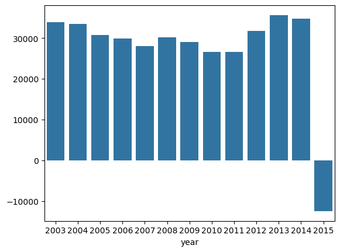

```python
# plot of year feature
sns.barplot(x=train.groupby('year').size().index, y=train.groupby('year').size().values - 40000)
```

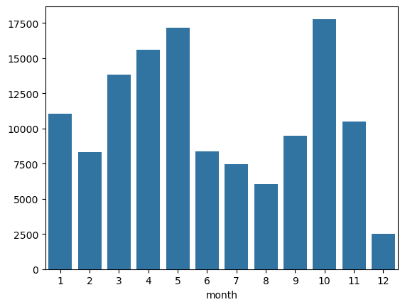

```python
# plot of month feature
sns.barplot(x=train.groupby('month').size().index, y=train.groupby('month').size().values -62500)
```

The months are not as evenly distributed as I expected them to be. Crimes happen a lot more in october and may compared to other months with the least amount being commited in December. This could be because of the holiday season and preparing for the holiday season in October because Theft is the most commonly commited crime in San Francisco.

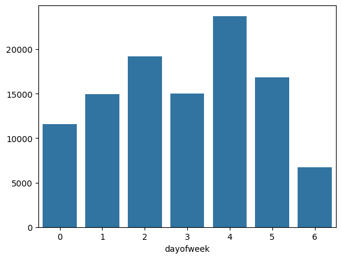

```python
# plot of day feature
sns.barplot(x=train.groupby('dayofweek').size().index, y=train.groupby('dayofweek').size().values - 110000)
```

```python
# looking at the different categories for prediction
pd.value_counts(train['Category'])
```

```
LARCENY/THEFT                  174900
OTHER OFFENSES                 126182
NON-CRIMINAL                    92304
ASSAULT                         76876
DRUG/NARCOTIC                   53971
VEHICLE THEFT                   53781
VANDALISM                       44725
WARRANTS                        42214
BURGLARY                        36755
SUSPICIOUS OCC                  31414
MISSING PERSON                  25989
ROBBERY                         23000
FRAUD                           16679
FORGERY/COUNTERFEITING          10609
SECONDARY CODES                  9985
WEAPON LAWS                      8555
PROSTITUTION                     7484
TRESPASS                         7326
STOLEN PROPERTY                  4540
SEX OFFENSES FORCIBLE            4388
DISORDERLY CONDUCT               4320
DRUNKENNESS                      4280
RECOVERED VEHICLE                3138
KIDNAPPING                       2341
DRIVING UNDER THE INFLUENCE      2268
RUNAWAY                          1946
LIQUOR LAWS                      1903
ARSON                            1513
LOITERING                        1225
EMBEZZLEMENT                     1166
SUICIDE                           508
FAMILY OFFENSES                   491
BAD CHECKS                        406
BRIBERY                           289
EXTORTION                         256
SEX OFFENSES NON FORCIBLE         148
GAMBLING                          146
PORNOGRAPHY/OBSCENE MAT            22
TREA                                6
Name: Category, dtype: int64
```

There are 39 different categories of crime. Theft is the top crime reported along with other, non-criminal, assult and narcotics to round out the top 5 crime categories.

[output not shown]

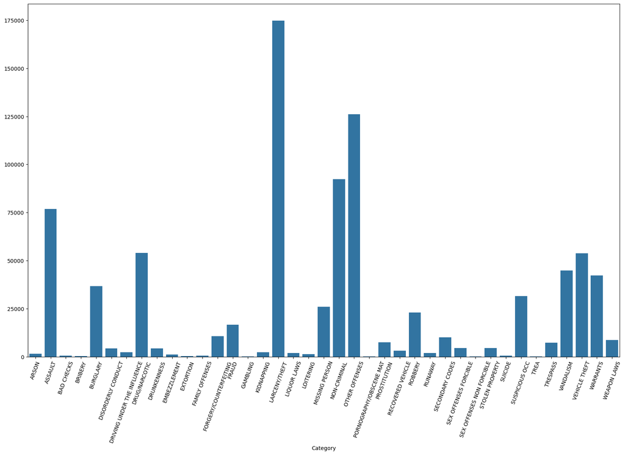

```python
# plot of category distribution
plt.subplots(figsize = (20,12))
sns.barplot(x=train.groupby('Category').size().index, y=train.groupby('Category').size().values)
plt.xticks(rotation=70)
```

I do not need to transform my data since I will be doing FNN and SVM and the format the data is already in should work well with this type of model analysis.

### Data Cleaning

I am going to clean the data by removing features with collinearities, seeing if there are too many null or NA values in this dataset and either fill them or remove the feature completely depending on severity. I will also look at if there are outliers in my dataset to see if that will affect my model accuracy. I am going to prepare my data for model building in this step by converting the data type to the appropriate type for prediction.

I am going to first look if there are any null values

```python
train.isnull().sum
```

```
<bound method NDFrame._add_numeric_operations.<locals>.sum of         Dates  Category  Descript  DayOfWeek  PdDistrict  Resolution  Address  \
0       False     False     False      False       False       False    False
1       False     False     False      False       False       False    False
2       False     False     False      False       False       False    False
3       False     False     False      False       False       False    False
4       False     False     False      False       False       False    False
...       ...       ...       ...        ...         ...         ...      ...
878044  False     False     False      False       False       False    False
878045  False     False     False      False       False       False    False
878046  False     False     False      False       False       False    False
878047  False     False     False      False       False       False    False
878048  False     False     False      False       False       False    False

            X      Y
0       False  False
1       False  False
2       False  False
3       False  False
4       False  False
...       ...    ...
878044  False  False
878045  False  False
878046  False  False
878047  False  False
878048  False  False

[878049 rows x 9 columns]>
```

```python
test.isnull().sum
```

```
<bound method NDFrame._add_numeric_operations.<locals>.sum of            Id  Dates  DayOfWeek  PdDistrict  Address      X      Y
0       False  False      False       False    False  False  False
1       False  False      False       False    False  False  False
2       False  False      False       False    False  False  False
3       False  False      False       False    False  False  False
4       False  False      False       False    False  False  False
...       ...    ...        ...         ...      ...    ...    ...
884257  False  False      False       False    False  False  False
884258  False  False      False       False    False  False  False
884259  False  False      False       False    False  False  False
884260  False  False      False       False    False  False  False
884261  False  False      False       False    False  False  False

[884262 rows x 7 columns]>
```

There are not any null values in this data set so I do not need to remove features because of null values.

I am going to start by removing some features from the train and test data sets. I am going to remove the X and Y coordinates because I feel they are not as important as other features for prediction based off of domain knowledge. I am also going to remove Address for this same reason. I am going to remove Resolution from the train data set because it is not in the test data set.

```python
# removing features that are not meaningful for prediction
train1 = train.drop(['X'], axis=1)
train1 = train1.drop(['Y'], axis=1)
train1 = train1.drop(['Resolution'], axis=1)
train1 = train1.drop(['Address'], axis=1)


test1 = test.drop(['X'], axis=1)
test1 = test1.drop(['Y'], axis=1)
test1 = test1.drop(['Address'], axis=1)
```

```python
train1.head()
```

[output not shown]

```python
test1.head()
```

|  | Id | Dates | DayOfWeek | PdDistrict |
| --- | --- | --- | --- | --- |
| 0 | 0 | 2015-05-10 23:59:00 | Sunday | BAYVIEW |
| 1 | 1 | 2015-05-10 23:51:00 | Sunday | BAYVIEW |
| 2 | 2 | 2015-05-10 23:50:00 | Sunday | NORTHERN |
| 3 | 3 | 2015-05-10 23:45:00 | Sunday | INGLESIDE |
| 4 | 4 | 2015-05-10 23:45:00 | Sunday | INGLESIDE |

```python
# looking at the data types to see if I need to transform them for model building
train1.dtypes
```

[output not shown]

```python
# doing a label encoder for prediction for each variable to convert into numerical values
from sklearn.preprocessing import LabelEncoder

# PdDistrict
le1 = LabelEncoder()
train1['PdDistrict'] = le1.fit_transform(train1['PdDistrict'])
test1['PdDistrict'] = le1.fit_transform(test1['PdDistrict'])

# Category
le2 = LabelEncoder()
train1['Category'] = le2.fit_transform(train1['Category'])

# Descript
le3 = LabelEncoder()
train1['Descript'] = le3.fit_transform(train1['Descript'])


# DayofWeek
le4 = LabelEncoder()
train1['DayOfWeek'] = le4.fit_transform(train1['DayOfWeek'])
test1['DayOfWeek'] = le4.fit_transform(test1['DayOfWeek'])
```

```python
train1.head()
```

|  | Dates | Category | Descript | DayOfWeek | PdDistrict | year | month | day | dayofweek | hour | minute |
| --- | --- | --- | --- | --- | --- | --- | --- | --- | --- | --- | --- |
| 0 | 2015-05-13 23:53:00 | 37 | 866 | 6 | 4 | 2015 | 5 | 13 | 2 | 23 | 53 |
| 1 | 2015-05-13 23:53:00 | 21 | 810 | 6 | 4 | 2015 | 5 | 13 | 2 | 23 | 53 |
| 2 | 2015-05-13 23:33:00 | 21 | 810 | 6 | 4 | 2015 | 5 | 13 | 2 | 23 | 33 |
| 3 | 2015-05-13 23:30:00 | 16 | 404 | 6 | 4 | 2015 | 5 | 13 | 2 | 23 | 30 |
| 4 | 2015-05-13 23:30:00 | 16 | 404 | 6 | 5 | 2015 | 5 | 13 | 2 | 23 | 30 |

```python
test1.head()
```

|  | Id | Dates | DayOfWeek | PdDistrict |
| --- | --- | --- | --- | --- |
| 0 | 0 | 2015-05-10 23:59:00 | 3 | 0 |
| 1 | 1 | 2015-05-10 23:51:00 | 3 | 0 |
| 2 | 2 | 2015-05-10 23:50:00 | 3 | 4 |
| 3 | 3 | 2015-05-10 23:45:00 | 3 | 2 |
| 4 | 4 | 2015-05-10 23:45:00 | 3 | 2 |

### Correlations of Features

```python
# correlation analysis
correlation_matrix = train1.corr()
```

```python
print(correlation_matrix)
```

```
            Category  Descript  DayOfWeek  PdDistrict      year     month  \
Category    1.000000  0.433396   0.000388   -0.040674 -0.021803  0.000008
Descript    0.433396  1.000000   0.010999    0.010074 -0.084447 -0.002613
DayOfWeek   0.000388  0.010999   1.000000    0.009571 -0.007491 -0.006860
PdDistrict -0.040674  0.010074   0.009571    1.000000  0.006722  0.001925
year       -0.021803 -0.084447  -0.007491    0.006722  1.000000 -0.048188
month       0.000008 -0.002613  -0.006860    0.001925 -0.048188  1.000000
day         0.000805  0.000123  -0.004388   -0.002074 -0.009738  0.016947
dayofweek   0.001078 -0.011449  -0.231703   -0.012786  0.014228  0.010685
hour        0.023524  0.041060  -0.001484    0.006215 -0.006257 -0.001896
minute     -0.021856  0.007506   0.016792    0.025924  0.019149 -0.008225

                 day  dayofweek      hour    minute
Category    0.000805   0.001078  0.023524 -0.021856
Descript    0.000123  -0.011449  0.041060  0.007506
DayOfWeek  -0.004388  -0.231703 -0.001484  0.016792
PdDistrict -0.002074  -0.012786  0.006215  0.025924
year       -0.009738   0.014228 -0.006257  0.019149
month       0.016947   0.010685 -0.001896 -0.008225
day         1.000000   0.010660  0.015680  0.009931
dayofweek   0.010660   1.000000 -0.021087 -0.014214
hour        0.015680  -0.021087  1.000000  0.010221
minute      0.009931  -0.014214  0.010221  1.000000
```

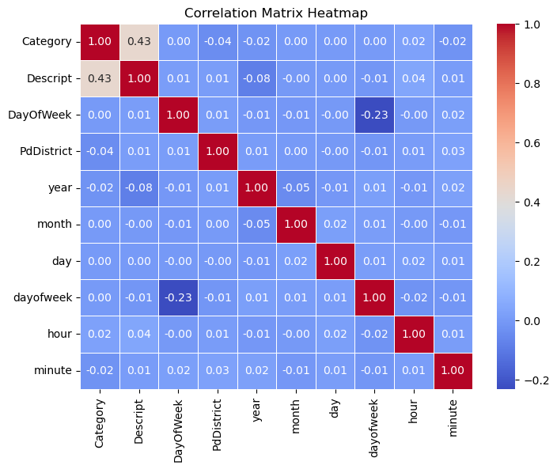

```python
# Create a heatmap
plt.figure(figsize=(8, 6))
sns.heatmap(correlation_matrix, annot=True, cmap='coolwarm', fmt='.2f', linewidths=.5)
plt.title('Correlation Matrix Heatmap')
plt.show()
```

There is almost no correlation between features so I will not need to remove any more features because of this. It is important for model accuracy that there is not multicollinearity of the features in the data set.

### Outliers

Seeing if there are outliers in my dataset features.

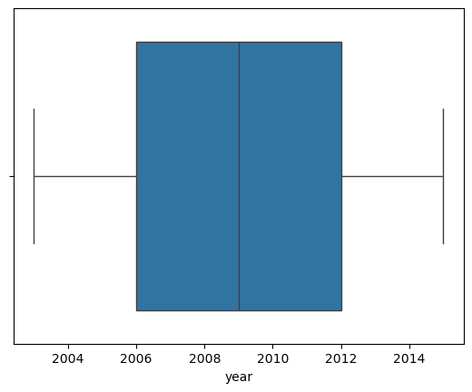

```python
sns.boxplot(x=train1['year'])
plt.show()
```

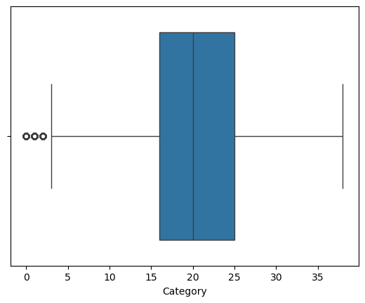

```python
sns.boxplot(x=train1['Category'])
plt.show()
```

It looks like there are a few outliers in the Category column but not enough to completly remove those rows from data modeling, they could be important for the data and I do not think they will cause a decrease in accuracy.

## Model

I am going to be creating a feedforward neural network model and also a SVM model in order to perform classification to predict which category of crime in the dataset.

Feedforward neural networks are commonly used for classification because they are flexible and are capable of modeling complex relationships within data. They can do non-linear classification which is good because this data isn't linear.

I think the support vector machine model will perform better than the feedforward neural network model because SVM models can perform the best on classification of datasets.

```python
# splitting data
X = train1.drop(['Category'], axis=1)
y = train1['Category']

X_train, X_test, y_train, y_test = train_test_split(X,y,test_size=0.1,random_state=42)
print(X_train.shape,y_train.shape)
print(X_test.shape,y_test.shape)
```

```
(790244, 10) (790244,)
(87805, 10) (87805,)
```

### Feedforward Neural Network

```python
# feedforward neural network
from keras.layers import Dense,Activation
from keras.models import Sequential

model = Sequential()
model.add(Dense(100, input_shape=(X.shape[1],)))
model.add(Activation('relu'))
model.add(Dense(100))
model.add(Activation('relu'))
model.add(Dense(80))
model.add(Activation('relu'))
model.add(Dense(60))
model.add(Activation('relu'))
model.add(Dense(39))
model.add(Activation('softmax'))
model.summary()
```

```
Model: "sequential"
_________________________________________________________________
 Layer (type)                Output Shape              Param #
=================================================================
 dense (Dense)               (None, 100)               1100

 activation (Activation)     (None, 100)               0

 dense_1 (Dense)             (None, 100)               10100

 activation_1 (Activation)   (None, 100)               0

 dense_2 (Dense)             (None, 80)                8080

 activation_2 (Activation)   (None, 80)                0

 dense_3 (Dense)             (None, 60)                4860

 activation_3 (Activation)   (None, 60)                0

 dense_4 (Dense)             (None, 39)                2379

 activation_4 (Activation)   (None, 39)                0

=================================================================
Total params: 26519 (103.59 KB)
Trainable params: 26519 (103.59 KB)
Non-trainable params: 0 (0.00 Byte)
_________________________________________________________________
```

```python
# complie the model
model.compile(optimizer='adam', loss='binary_crossentropy', metrics=['accuracy'])
```

```python
# fit the model
fit = model.fit(X_train, y_train, epochs=1, batch_size=32, validation_data=(X_test, y_test))
```

```python
# finding model accuaracy
test_loss, test_acc = model.evaluate(X_test, y_test)
print(f'Test Accuracy: {test_accuracy}')
```

[output not shown]

### Support Vector Machine

```python
from sklearn import svm
from sklearn.model_selection import train_test_split
from sklearn.preprocessing import StandardScaler
from sklearn.metrics import accuracy_score, classification_report
```

```python
# splitting the dataset
X_train2, X_test2, y_train2, y_test2 = train_test_split(X_train, y_train, test_size=0.2, random_state=42)
```

```python
# Create an SVM classifier
svm_model = svm_model.SVC(kernel='rbf')
```

```python
# Train the SVM model
svm_model.fit(X_train2, y_train2)
```

```python
# making predictions with this model on the test set
y_pred = svm_model.predict(X_test2)
```

```python
# Evaluate the model accuracy
accuracy = accuracy_score(y_test, y_pred)

print(f'Accuracy: {accuracy}')
```

[output not shown]

## Results and Analysis

### Accuracy

Accuracy for SVM was 78.52% Accuracy for Feed forward neural network is 67.41%

### Hyperparameter Tuning

I am going to change the hyperparameter of the kernel of my SVM model to sigmoid to see if it performs better.

```python
# Create an SVM classifier
svm_model2 = svm_model2.SVC(kernel='sigmoid')

# Train the SVM model
svm_model2.fit(X_train2, y_train2)

# making predictions with this model on the test set
y_pred = svm_model2.predict(X_test2)

# Evaluate the model accuracy
accuracy2 = accuracy_score(y_test, y_pred)

print(f'Accuracy: {accuracy2}')
```

[output not shown]

The accuracy is slightly lower when I change the hyperparameter for the SVM model.

## Conclusions

A support vector machine is not a neural network but a feedforward network is one of the most common and simplisit neural network. Maybe a chose a dataset that doesn't perform best with deep learning and does better with supervised machine learning. Or, I could have chose a better deep learning neural network model to use for classification for this data set.

In the furture I would run multiple differnet types of neural networks that perform well for text classification like a LSTM model or a RNN or a GRU. These could have performed better than the feedforward neural network model and all the SVM model.